# Econ 3110: Problem Set 5 Solutions

## Question 1 (5 points)

### (a) Net lifetime utility

The gross lifetime utility from buying the Switch 2 at time $\bar{t}$ is the discounted sum of flow utilities: $$ U(\bar{t}) = \sum_{t=\bar{t}}^{\bar{t}+9} \beta^t u^{**} + \sum_{t=\bar{t}+10}^{\infty} \beta^t u^{*} $$

We can simplify this using the formulas for geometric series: $$ U(\bar{t}) = u^{**} \left( \frac{\beta^{\bar{t}} - \beta^{\bar{t}+10}}{1-\beta} \right) + u^{*} \left( \frac{\beta^{\bar{t}+10}}{1-\beta} \right) $$

The utility cost of purchasing at $\bar{t}$ is $c_{\bar{t}} = \frac{5}{1-\beta} + \frac{4}{\bar{t}}$. The present discounted value of this cost at $t=0$ is $\beta^{\bar{t}}c_{\bar{t}}$.

The net lifetime utility, $V(\bar{t})$, from the perspective of today ($t=0$) is: $$ V(\bar{t}) = U(\bar{t}) - \beta^{\bar{t}}c_{\bar{t}} = u^{**} \left( \frac{\beta^{\bar{t}} - \beta^{\bar{t}+10}}{1-\beta} \right) + u^{*} \left( \frac{\beta^{\bar{t}+10}}{1-\beta} \right) - \beta^{\bar{t}} \left( \frac{5}{1-\beta} + \frac{4}{\bar{t}} \right) $$ $$ V(\bar{t}) = \frac{\beta^{\bar{t}}}{1-\beta} \left[ u^{**}(1-\beta^{10}) + u^{*}\beta^{10} - 5 - \frac{4(1-\beta)}{\bar{t}} \right] $$

### (b) Optimal choice of $\bar{t}$

Suppose $u^{*} = u^{**} = 6$. The net lifetime utility expression from part (a) simplifies significantly. The two utility terms in the summation become a single infinite geometric series: $$ U(\bar{t}) = \sum_{t=\bar{t}}^{\infty} \beta^t (6) = \frac{6\beta^{\bar{t}}}{1-\beta} $$ The net utility is: $$ V(\bar{t}) = \frac{6\beta^{\bar{t}}}{1-\beta} - \beta^{\bar{t}} \left( \frac{5}{1-\beta} + \frac{4}{\bar{t}} \right) = \beta^{\bar{t}} \left( \frac{6-5}{1-\beta} - \frac{4}{\bar{t}} \right) = \beta^{\bar{t}} \left( \frac{1}{1-\beta} - \frac{4}{\bar{t}} \right) $$ To find the $\bar{t}$ that maximizes this, we can treat $\bar{t}$ as a continuous variable and take the derivative with respect to $\bar{t}$ and set it to zero: $$ \frac{dV}{d\bar{t}} = (\ln\beta) \beta^{\bar{t}} \left( \frac{1}{1-\beta} - \frac{4}{\bar{t}} \right) + \beta^{\bar{t}} \left( \frac{4}{\bar{t}^2} \right) = 0 $$ Dividing by $\beta^{\bar{t}}$ (which is non-zero): $$ (\ln\beta) \left( \frac{1}{1-\beta} - \frac{4}{\bar{t}} \right) + \frac{4}{\bar{t}^2} = 0 $$ $$ \frac{\ln\beta}{1-\beta} - \frac{4\ln\beta}{\bar{t}} + \frac{4}{\bar{t}^2} = 0 $$ Multiplying by $\bar{t}^2$ gives a quadratic equation in $\bar{t}$: $$ \left( \frac{\ln\beta}{1-\beta} \right) \bar{t}^2 - (4\ln\beta) \bar{t} + 4 = 0 $$ Using the quadratic formula, $\bar{t} = \frac{-b \pm \sqrt{b^2-4ac}}{2a}$: $$ \bar{t} = \frac{4\ln\beta \pm \sqrt{(-4\ln\beta)^2 - 4(\frac{\ln\beta}{1-\beta})(4)}}{2(\frac{\ln\beta}{1-\beta})} = \frac{4\ln\beta \pm \sqrt{16(\ln\beta)^2 - \frac{16\ln\beta}{1-\beta}}}{2(\frac{\ln\beta}{1-\beta})} $$ $$ \bar{t} = (2\ln\beta \pm 2\sqrt{(\ln\beta)^2 - \frac{\ln\beta}{1-\beta}})\frac{1-\beta}{\ln\beta} = 2(1-\beta) \left( 1 \pm \sqrt{1 - \frac{1}{(1-\beta)\ln\beta}} \right) $$

### (c) Economic intuition

A higher $\beta$ means an individual is more patient and values future utility streams more. This increased valuation of the future makes the prospect of starting the flow of utility from the Switch 2 more attractive sooner. While waiting reduces a small part of the cost (the $\frac{4}{\bar{t}}$ term), a more patient individual finds the opportunity cost of delaying the entire stream of future utility to be higher. Therefore, a higher $\beta$ encourages an earlier purchase to begin enjoying the benefits sooner, causing the optimal $\bar{t}$ to decrease.

### (d) Implied discount rate

The discount factor for one period is $\beta$. The discount factor for $n$ periods is $\beta^n$. The discount rate $r$ is related by $\beta^n = \frac{1}{1+r_{total}}$. So, $r_{total} = \frac{1}{\beta^n} - 1$.

```
If a period is one day:
The implied yearly discount factor is: 1.9885e-17
The implied annual discount rate is: 50290280116685232.0000 or 5029028011668523008.00%

If a period is one month:
The implied yearly discount factor is: 0.2824
The implied annual discount rate is: 2.5407 or 254.07%
```

When each period represents one month instead of one day, the implied discount rate for a year is significantly lower. This is because the high discount rate is compounded 12 times instead of 365 times, leading to less severe discounting over the same one-year horizon.

## Question 2 (4 points)

### (a) Demand functions and quantities

The utility function is $u(S, G) = \sqrt{SG} = S^{0.5}G^{0.5}$, which is a Cobb-Douglas utility function. For a general Cobb-Douglas function $u(S,G) = S^a G^b$, the demand functions are: $$ S^*(p_S, p_G, M) = \frac{a}{a+b} \frac{M}{p_S} \quad \text{and} \quad G^*(p_S, p_G, M) = \frac{b}{a+b} \frac{M}{p_G} $$ Here, $a=0.5$ and $b=0.5$, so $a+b=1$. The demand functions are: $$ S^*(p_S, p_G, M) = \frac{0.5}{1} \frac{M}{p_S} = \frac{M}{2p_S} $$ $$ G^*(p_S, p_G, M) = \frac{0.5}{1} \frac{M}{p_G} = \frac{M}{2p_G} $$ Given $p_S = 300$, $p_G = 300$, and $M=6000$, the quantities demanded are: $$ S^* = \frac{6000}{2(300)} = \frac{6000}{600} = 10 $$ $$ G^* = \frac{6000}{2(300)} = \frac{6000}{600} = 10 $$

### (b) Indirect utility function

Substitute the demand functions into the utility function: $$ v(p_S, p_G, M) = u(S^*, G^*) = \sqrt{\left(\frac{M}{2p_S}\right) \left(\frac{M}{2p_G}\right)} = \sqrt{\frac{M^2}{4p_S p_G}} = \frac{M}{2\sqrt{p_S p_G}} $$

### (c) Compensating Variation (CV)

First, calculate the cost of the original bundle $(S=10, G=10)$ at the new prices ($p'_S = 400, p'_G = 150$): $$ M' = p'_S S + p'_G G = 400(10) + 150(10) = 4000 + 1500 = 5500 $$ The wealth needed to afford the original bundle is $5500.

Compensating variation (CV) is the change in income that would make the consumer indifferent between the old prices and the new prices. First find the original utility level: $$ u_0 = u(10, 10) = \sqrt{10 \times 10} = 10 $$ Now find the income $M_{CV}$ needed to achieve $u_0=10$ at the new prices using the indirect utility function: $$ 10 = v(400, 150, M_{CV}) = \frac{M_{CV}}{2\sqrt{400 \times 150}} = \frac{M_{CV}}{2\sqrt{60000}} = \frac{M_{CV}}{200\sqrt{6}} $$ $$ M_{CV} = 2000\sqrt{6} $$ The CV is the difference between this hypothetical income and the original income: $$ CV = M_{CV} - M = 2000\sqrt{6} - 6000 $$

```
The income needed to achieve the original utility is M_CV = $4898.98
The Compensating Variation (CV) is $-1101.02
```

### (d) Equivalent Variation (EV)

First, find Ash's optimal bundle at the new prices ($p'_S = 400, p'_G = 150$) and original income ($M=6000$): $$ S'^* = \frac{6000}{2(400)} = 7.5 $$ $$ G'^* = \frac{6000}{2(150)} = 20 $$ Next, calculate the utility level at this new bundle: $$ u_1 = u(7.5, 20) = \sqrt{7.5 \times 20} = \sqrt{150} = 5\sqrt{6} $$ Equivalent variation (EV) is the change in income at the *original* prices that would yield the same utility as the new price regime. We find the income $M_{EV}$ that gives utility $u_1$ at the old prices ($p_S=300, p_G=300$): $$ 5\sqrt{6} = v(300, 300, M_{EV}) = \frac{M_{EV}}{2\sqrt{300 \times 300}} = \frac{M_{EV}}{600} $$ $$ M_{EV} = 3000\sqrt{6} $$ The EV is the difference between the original income and this hypothetical income: $$ EV = M - M_{EV} = 6000 - 3000\sqrt{6} $$

```
The income at original prices yielding the new utility is M_EV = $7348.47
The Equivalent Variation (EV) is $-1348.47
```

## Question 3 (5 points)

### (a) Marginal Rate of Substitution (MRS)

The utility function is $u(x, y) = (x^\rho + y^\rho)^{1/\rho}$. The marginal utilities are: $$ MU_x = \frac{\partial u}{\partial x} = \frac{1}{\rho}(x^\rho + y^\rho)^{1/\rho - 1}(\rho x^{\rho-1}) = (x^\rho + y^\rho)^{1/\rho - 1} x^{\rho-1} $$ $$ MU_y = \frac{\partial u}{\partial y} = \frac{1}{\rho}(x^\rho + y^\rho)^{1/\rho - 1}(\rho y^{\rho-1}) = (x^\rho + y^\rho)^{1/\rho - 1} y^{\rho-1} $$ The MRS is the ratio of the marginal utilities: $$ MRS_{x,y} = \frac{MU_x}{MU_y} = \frac{(x^\rho + y^\rho)^{1/\rho - 1} x^{\rho-1}}{(x^\rho + y^\rho)^{1/\rho - 1} y^{\rho-1}} = \frac{x^{\rho-1}}{y^{\rho-1}} = \left(\frac{x}{y}\right)^{\rho-1} $$

### (b) Elasticity of substitution

The elasticity of substitution $\epsilon$ is defined as $\epsilon = \frac{d \ln(y/x)}{d \ln(MRS_{x,y})}$. From part (a), we have $MRS_{x,y} = (x/y)^{\rho-1} = (y/x)^{1-\rho}$. Take the natural logarithm of both sides: $$ \ln(MRS_{x,y}) = (1-\rho) \ln(y/x) $$ Rearrange the expression to get $\ln(y/x)$ in terms of $\ln(MRS_{x,y})$: $$ \ln(y/x) = \frac{1}{1-\rho} \ln(MRS_{x,y}) $$ Now, we can find the elasticity by differentiating: $$ \epsilon = \frac{d \ln(y/x)}{d \ln(MRS_{x,y})} = \frac{1}{1-\rho} $$

### (c) Case $\rho \rightarrow 1$

As $\rho \rightarrow 1$, the denominator of the elasticity expression approaches zero: $1-\rho \rightarrow 0$. Therefore, $\epsilon = \frac{1}{1-\rho} \rightarrow \infty$. An infinite elasticity of substitution means the goods are **perfect substitutes**. When $\rho = 1$, the utility function becomes $u(x,y) = x+y$, which represents perfect substitutes.

### (d) Case $\rho \rightarrow -\infty$

As $\rho \rightarrow -\infty$, the denominator of the elasticity expression approaches infinity: $1-\rho \rightarrow \infty$. Therefore, $\epsilon = \frac{1}{1-\rho} \rightarrow 0$. An elasticity of substitution of zero means the goods are **perfect complements**. This utility function approaches the Leontief form, $u(x,y) = \min\{x,y\}$, as $\rho \rightarrow -\infty$.

## Question 4 (5 points)

### (a) Aggregate demand from inverse demand

The inverse demand for consumer $j$ is $p_x = M_j - \frac{x_j}{\beta}$. We can find the direct demand function for consumer $j$ by solving for $x_j$: $$ \frac{x_j}{\beta} = M_j - p_x \implies x_j(p_x, M_j) = \beta(M_j - p_x) $$ Demand is only positive if $M_j > p_x$. The aggregate demand $X$ is the sum of individual demands for all consumers who are in the market at a given price $p_x$. $$ X(p_x) = \sum_{j \text{ s.t. } M_j > p_x} x_j = \sum_{j \text{ s.t. } M_j > p_x} \beta(M_j - p_x) $$

### (b) Aggregate demand with quasilinear utility

The utility function is $u_j(x,y) = j \ln(x) + y$. The prices are $p_x$ and $p_y=1$. The MRS is $MRS_{x,y} = \frac{MU_x}{MU_y} = \frac{j/x}{1} = \frac{j}{x}$. Setting $MRS = \frac{p_x}{p_y}$: $$ \frac{j}{x_j} = \frac{p_x}{1} \implies x_j(p_x) = \frac{j}{p_x} $$ (The condition $M_j > j$ ensures an interior solution). The aggregate demand is the sum of individual demands: $$ X(p_x) = \sum_{j=1}^{n} x_j = \sum_{j=1}^{n} \frac{j}{p_x} = \frac{1}{p_x} \sum_{j=1}^{n} j $$ Using the formula for the sum of the first $n$ integers, $\sum_{j=1}^{n} j = \frac{n(n+1)}{2}$: $$ X(p_x) = \frac{n(n+1)}{2p_x} $$

### (c) Aggregate demand with Cobb-Douglas utility

The utility function $u_j(x,y) = \sqrt{xy} = x^{0.5}y^{0.5}$ is the same for all consumers. The demand for good $x$ for a consumer with income $M_j$ is: $$ x_j(p_x, M_j) = \frac{0.5}{0.5+0.5} \frac{M_j}{p_x} = \frac{M_j}{2p_x} $$ The aggregate demand is the sum of these individual demands: $$ X(p_x) = \sum_{j=1}^{n} x_j = \sum_{j=1}^{n} \frac{M_j}{2p_x} = \frac{1}{2p_x} \sum_{j=1}^{n} M_j $$

## Question 5 (5 points)

### (a) Equilibrium price and quantity

Demand: $Q_d = a - b\sqrt{P}$ Supply: $Q_s = c + d\sqrt{P}$ In equilibrium, $Q_d = Q_s$: $$ a - b\sqrt{P} = c + d\sqrt{P} $$ $$ a - c = (b+d)\sqrt{P} $$ Solving for the equilibrium price $P^*$: $$ \sqrt{P^*} = \frac{a-c}{b+d} \implies P^* = \left( \frac{a-c}{b+d} \right)^2 $$ Substitute $\sqrt{P^*}$ back into the supply equation to find the equilibrium quantity $Q^*$: $$ Q^* = c + d \left( \frac{a-c}{b+d} \right) = \frac{c(b+d) + d(a-c)}{b+d} = \frac{cb + cd + ad - cd}{b+d} = \frac{ad+bc}{b+d} $$

### (b) Equilibrium with a tax

With a tax rate $\tau$ paid by buyers, the price they pay is $P_b = (1+\tau)P_s$, where $P_s$ is the price sellers receive. The demand equation becomes a function of $P_s$: $$ Q_d = a - b\sqrt{(1+\tau)P_s} $$ Setting demand equal to supply, $Q_s = c + d\sqrt{P_s}$: $$ a - b\sqrt{1+\tau}\sqrt{P_s} = c + d\sqrt{P_s} $$ $$ a - c = (b\sqrt{1+\tau} + d)\sqrt{P_s} $$ The new equilibrium price for sellers, $P'_s$, is: $$ P'_s = \left( \frac{a-c}{b\sqrt{1+\tau} + d} \right)^2 $$ The new equilibrium quantity, $Q'$, is: $$ Q' = c + d\sqrt{P'_s} = c + d\left(\frac{a-c}{b\sqrt{1+\tau} + d}\right) = \frac{ad + bc\sqrt{1+\tau}}{d + b\sqrt{1+\tau}} $$

**Illustration:**

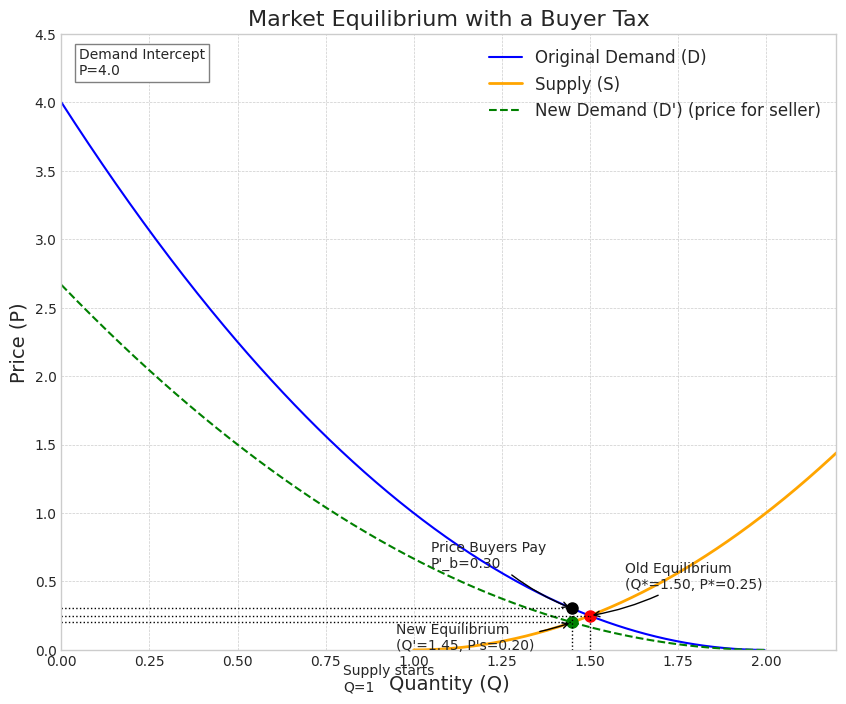

### (c) Consumer surplus calculation

Given $a=2, b=1, c=1, d=1, \tau=1/2$.

**Before Tax:** $$ P^* = \left( \frac{2-1}{1+1} \right)^2 = \left( \frac{1}{2} \right)^2 = 0.25 $$ To calculate consumer surplus, we integrate the area between the demand curve and the equilibrium price. The inverse demand curve is $P_d(Q) = (a-Q/b)^2 = (2-Q)^2$. The maximum price (choke price) is when $Q=0$, so $P_{max}=4$. $$ CS_{old} = \int_{P^*}^{P_{max}} Q_d(P) dP = \int_{0.25}^{4} (2-\sqrt{P}) dP $$ $$ CS_{old} = \left[ 2P - \frac{2}{3}P^{3/2} \right]_{0.25}^{4} = \left(2(4)-\frac{2}{3}(4)^{3/2}\right) - \left(2(0.25)-\frac{2}{3}(0.25)^{3/2}\right) $$ $$ CS_{old} = \left(8-\frac{16}{3}\right) - \left(0.5-\frac{2}{3}(0.125)\right) = \frac{8}{3} - \left(\frac{1}{2}-\frac{1}{12}\right) = \frac{8}{3} - \frac{5}{12} = \frac{32-5}{12} = \frac{27}{12} = 2.25 $$

**After Tax:** The tax is $\tau=0.5$, so $1+\tau = 1.5$. The new price for sellers is: $$ P'_s = \left( \frac{2-1}{1\sqrt{1.5} + 1} \right)^2 = \frac{1}{(1+\sqrt{1.5})^2} $$ The new price for buyers is $P'_b = (1.5)P'_s = \frac{1.5}{(1+\sqrt{1.5})^2}$. $$ CS_{new} = \int_{P'_b}^{4} (2-\sqrt{P}) dP = \left[ 2P - \frac{2}{3}P^{3/2} \right]_{P'_b}^{4} = \frac{8}{3} - \left( 2P'_b - \frac{2}{3}(P'_b)^{3/2} \right) $$

```
Consumer surplus before tax (CS_old): 2.2500
The new price for buyers is P'_b: 0.3031
Consumer surplus after tax (CS_new): 2.1718
The percentage change in consumer surplus is: -3.48%
```

## Question 6 (6 points)

### (a) Returns to scale

Let's scale all inputs by a factor $t > 1$. The new output is: $$ Y(tK, tL) = (tK)^{\alpha}(tL)^{\beta} = t^{\alpha}K^{\alpha}t^{\beta}L^{\beta} = t^{\alpha+\beta} K^{\alpha}L^{\beta} = t^{\alpha+\beta} Y(K,L) $$ The returns to scale depend on the value of $\alpha+\beta$:

- **Increasing returns-to-scale (IRS):** if $\alpha+\beta > 1$
- **Decreasing returns-to-scale (DRS):** if $\alpha+\beta < 1$
- **Constant returns-to-scale (CRS):** if $\alpha+\beta = 1$

### (b) MRTS

$$ MP_L = \frac{\partial Y}{\partial L} = \beta K^{\alpha}L^{\beta-1} $$ $$ MP_K = \frac{\partial Y}{\partial K} = \alpha K^{\alpha-1}L^{\beta} $$ $$ MRTS_{LK} = \frac{MP_L}{MP_K} = \frac{\beta K^{\alpha}L^{\beta-1}}{\alpha K^{\alpha-1}L^{\beta}} = \frac{\beta}{\alpha} \frac{K}{L} $$

### (c) Optimal choice of labor and capital

With $\alpha \in (0,1)$ and $\beta = 1-\alpha$, we have $\alpha+\beta=1$, so the production technology exhibits constant returns to scale (CRS). A profit-maximizing firm with a CRS production function faces a dilemma: if the maximum profit is positive, it would want to produce an infinite amount; if it's negative, it would produce zero. A non-trivial solution exists only if the maximum profit is exactly zero. This occurs when the price equals the marginal cost. The conditions for profit maximization are $p \cdot MP_L = w$ and $p \cdot MP_K = r$. Dividing these two conditions gives the tangency condition: $\frac{MP_L}{MP_K} = \frac{w}{r}$, so $\frac{\beta}{\alpha} \frac{K}{L} = \frac{w}{r}$. This defines the optimal capital-labor ratio: $\frac{K}{L} = \frac{\alpha w}{\beta r}$. However, because of CRS, the absolute levels of $L^*$ and $K^*$ are indeterminate from profit maximization alone. Any combination of $K$ and $L$ that satisfies the optimal ratio will result in zero economic profit. The scale of the firm is not determined.

### (d) Labor demand with fixed capital

With $K=4, p=6, w=2, r=2,$ and $\alpha=1/2$ (so $\beta=1/2$), the production function is $Y = 4^{1/2}L^{1/2} = 2\sqrt{L}$. The firm's profit function is: $$ \pi = pY - wL - rK = 6(2\sqrt{L}) - 2L - 2(4) = 12\sqrt{L} - 2L - 8 $$ To maximize profit, we take the derivative with respect to $L$ and set it to zero: $$ \frac{d\pi}{dL} = 12\left(\frac{1}{2\sqrt{L}}\right) - 2 = 0 $$ $$ \frac{6}{\sqrt{L}} = 2 \implies \sqrt{L} = 3 \implies L = 9 $$ The optimal level of labor is 9 units.

### (e) Change with a fixed cost

A fixed cost $\mathcal{F}$ does not depend on the level of inputs, so it does not affect the profit-maximizing choice of labor. The derivative of the profit function with respect to $L$ is unchanged, so the level of labor that maximizes operating profit is still $L=9$. However, the firm will only choose to operate if its total profit is non-negative. First, let's calculate the maximized operating profit (profit before the fixed cost $\mathcal{F}$): $$ \pi_{op} = 12\sqrt{9} - 2(9) - 8 = 12(3) - 18 - 8 = 36 - 26 = 10 $$ Now consider the total profit, $\pi_{total} = \pi_{op} - \mathcal{F}$.

- **If $\mathcal{F} = 5$**: $\pi_{total} = 10 - 5 = 5$. Since profit is positive, the firm will operate and hire $L=9$. The answer does not change.
- **If $\mathcal{F} = 15$**: $\pi_{total} = 10 - 15 = -5$. Since profit is negative, the firm is better off shutting down (producing zero) to avoid the variable costs and earn a profit of $-\mathcal{F}$ if the cost is sunk, or 0 if it is avoidable. Assuming the firm can avoid all costs by not producing, it will shut down. In this case, the labor hired is $L=0$. The answer changes from 9 to 0.